# Problems in school reported by children in regular and hospital schools

Judith Janschewski (TU Dortmund) and Philipp Berens (Uni T?bingen)

# Dataset

The dataset contains questionnaire responses of 573 students from regular and hospital schools. The following tables provides an overview:

| gender | N |
| --- | --- |
| female | 288 |
| male | 217 |
| NA | 68 |

| school_type | N |
| --- | --- |
| A | 388 |
| K | 185 |

| gender | school_type | N |
| --- | --- | --- |
| female | A | 179 |
| female | K | 109 |
| male | A | 162 |
| male | K | 55 |
| NA | A | 47 |
| NA | K | 21 |

| age | N |
| --- | --- |
| 11-12 | 60 |
| 13-14 | 205 |
| 15-16 | 167 |
| 17-18 | 110 |
| NA | 31 |

# Validating the SDQ results

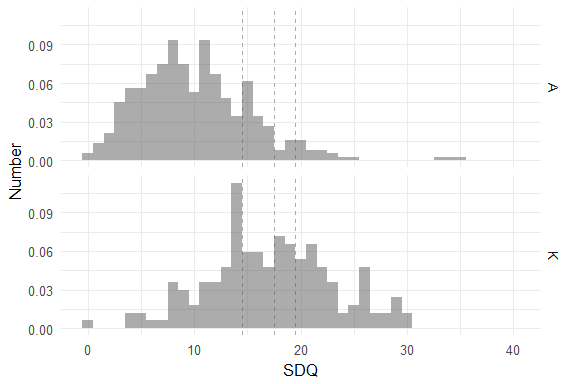

The cumulative SDQ distributions of general (A) and hosptial (K) schools show a clear shift between the two student populations:

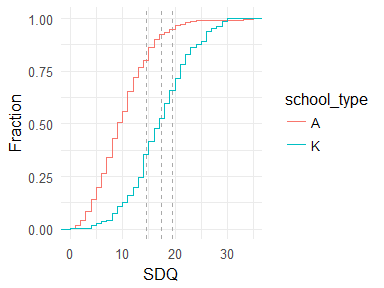

The percentage of students with raised SDQ in general schools corresponds approximately to that expected:

| school_type | N | fraction_raised | fraction_vhigh |
| --- | --- | --- | --- |
| A | 388 | 0.1973333 | 0.05066667 |
| K | 185 | 0.6428571 | 0.33928571 |

# Overview of item responses

We first provide an overview of several of the response items.

## Social problems

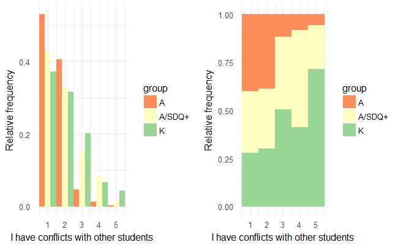

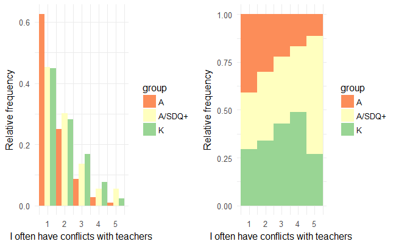

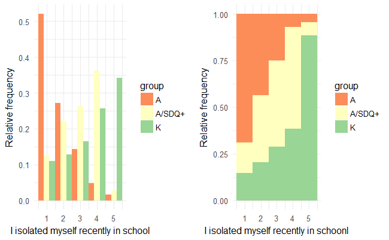

[figure not shown]

| group | N | conflict_stud | conflict_teach | isolation | large_groups |
| --- | --- | --- | --- | --- | --- |
| A | 301 | 1.553691 | 1.545151 | 1.768707 | 1.619048 |
| A/SDQ+ | 74 | 1.931507 | 1.958904 | 2.944444 | 2.486486 |
| K | 168 | 2.091463 | 1.946108 | 3.591463 | 3.047904 |

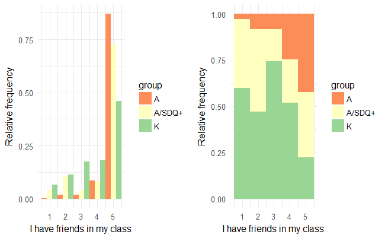

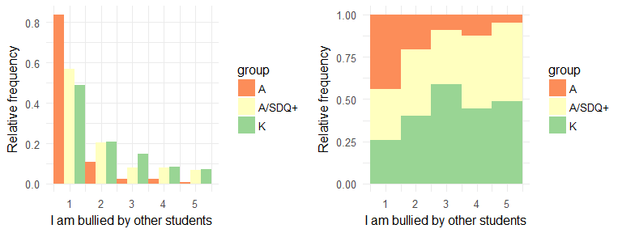

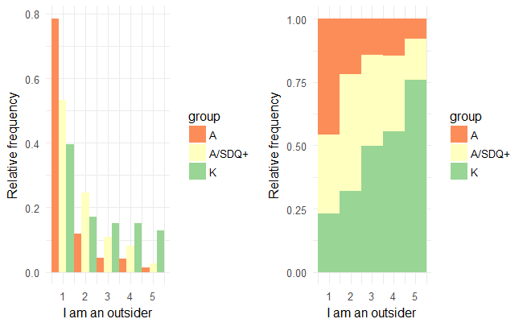

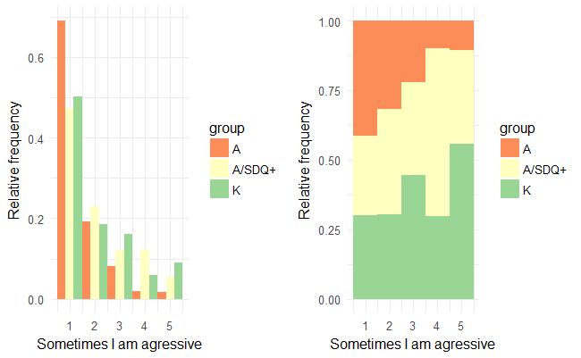

| group | N | friends | bullying | outsider | agressive |
| --- | --- | --- | --- | --- | --- |
| A | 301 | 4.800000 | 1.253378 | 1.380471 | 1.481481 |
| A/SDQ+ | 74 | 4.342466 | 1.878378 | 1.821918 | 2.054054 |
| K | 168 | 3.854545 | 2.041667 | 2.445122 | 2.047904 |

## School performance

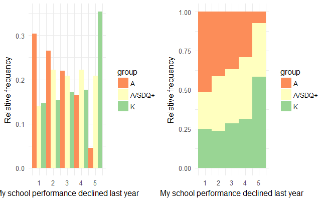

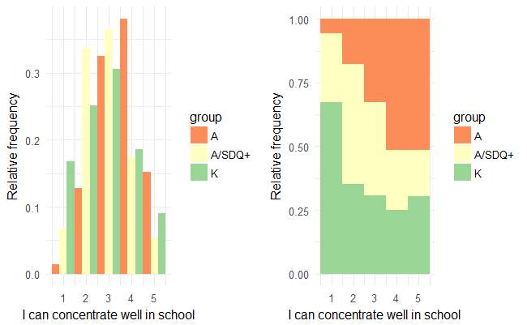

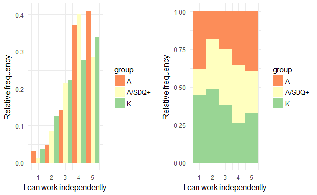

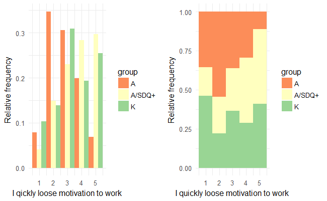

| group | N | perf_down | concentrate | independent | loose_mot |
| --- | --- | --- | --- | --- | --- |
| A | 301 | 2.381119 | 3.529412 | 4.078231 | 2.831615 |
| A/SDQ+ | 74 | 3.138889 | 2.810811 | 3.857143 | 3.648649 |
| K | 168 | 3.439024 | 2.778443 | 3.753012 | 3.357576 |

## Wellbeing/attitude

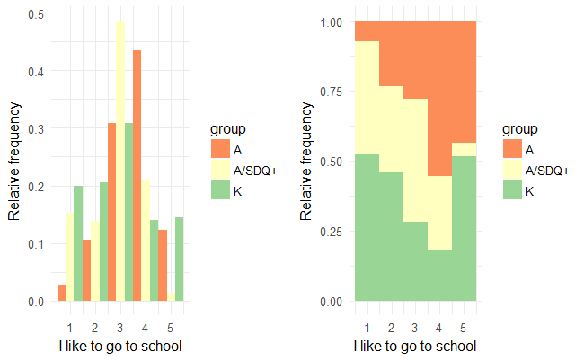

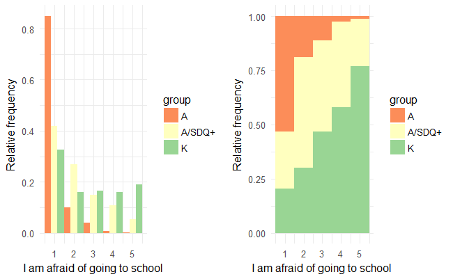

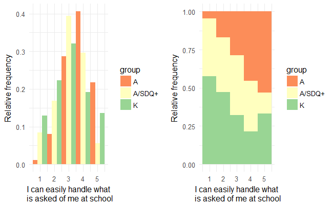

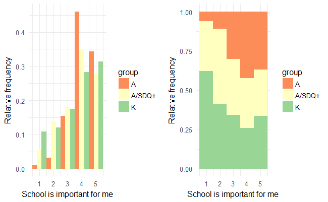

| group | N | like_school | afraid | handle | important |
| --- | --- | --- | --- | --- | --- |
| A | 301 | 3.520548 | 1.214765 | 3.737762 | 4.094737 |
| A/SDQ+ | 74 | 2.791667 | 2.108108 | 3.070423 | 3.652778 |
| K | 168 | 2.824242 | 2.730061 | 2.981481 | 3.572289 |

## Other items

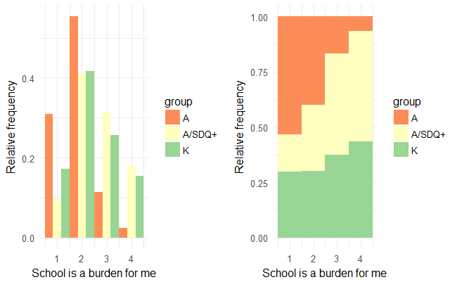

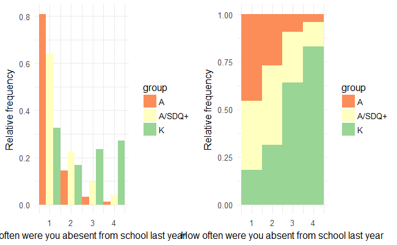

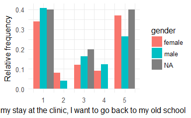

[output not shown]

# Classification between healthy students and students with psychological problems

We have quite a few missing values in the predictor variables. For now, we impute them using the mice package [link](https://www.jstatsoft.org/article/view/v045i03).

# SDQ Prediction

We have quite a few missing values in the predictor variables. For now, we impute them using the mice package [link](https://www.jstatsoft.org/article/view/v045i03).

We try to predict total, internal and external SDQ score from the response items using the glmnet package [link](http://web.stanford.edu/~hastie/glmnet/glmnet_alpha.html).

Predictive of a high score on the internalizing SDQ scale are (in order of decreasing weight):

- I am afraid to go to school
- I isolated myself recently
- School is a burden for me
- I don’t like large groups like my class
- I have friends in my class
- I am an outsider
- I am bullied by other students

Predictive of a high score an the externalizing SDQ scale are:

- I have conflicts with teachers
- I can work independently
- My school performance dropped during the last year
- I have conflicts with other students

Interesting is “I can easily handle what is asked of me at school” - it is not strongly predictive for either internalizing/externalizing, but highly predictive of the total score. Most other items that are preditive for one are also predictive for the total.

The correlation between the original values and the predictions is high (total: 0.603044, internal: 0.8001, external: 0.6314871), indicating good prediction.

# Support through teachers

| school_type | N | nans | fraction |
| --- | --- | --- | --- |
| A | 375 | 221 | 0.5893333 |
| K | 168 | 44 | 0.2619048 |

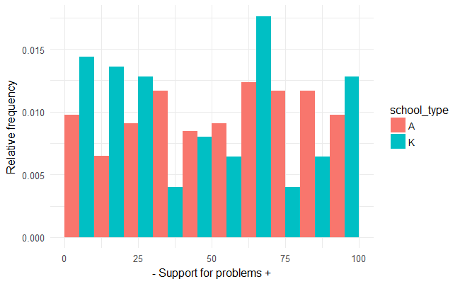

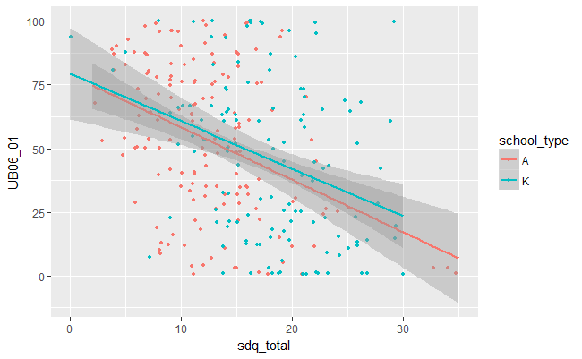

The spearman correlation is -0.3630675 for total SDQ, -0.3363001 for internalizing SDQ and -0.2026263 for externalizing SDQ.

```
Call:
lm(formula = UB06_01 ~ sdq_total + school_type, data = data)

Residuals:
    Min      1Q  Median      3Q     Max
-60.451 -20.886  -0.053  20.278  75.791

Coefficients:
             Estimate Std. Error t value Pr(>|t|)
(Intercept)    77.674      4.395  17.674  < 2e-16 ***
sdq_total      -1.966      0.301  -6.530 3.16e-10 ***
school_typeK    3.536      3.805   0.929    0.354
---
Signif. codes:  0 â€˜***â€™ 0.001 â€˜**â€™ 0.01 â€˜*â€™ 0.05 â€˜.â€™ 0.1 â€˜ â€™ 1

Residual standard error: 28.34 on 275 degrees of freedom
  (295 observations deleted due to missingness)
Multiple R-squared:  0.1467,    Adjusted R-squared:  0.1405
F-statistic: 23.64 on 2 and 275 DF,  p-value: 3.373e-10
```

[output not shown]

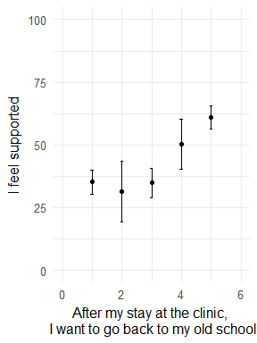

# I want to go back to school vs I feel supported by my teachers

# Predict I feel supported from positive and negative properties

# Exploratory factor analysis

- PA1: Affinity to school and a well-being at school
- PA2: Ability to cope with school demands
- PA3: Social integration
- PA4: Aggressive Behavior